# Linear Regression

Sean Schilk

10/24/2025

We start by changing the directory to wherever your data set is located. Then we load the tidyverse package so that we can use the ggplot function. You only need to install packages one time! But you have to load them every time you start a new session. Finally, we read in the data set and call it `athlete`.

```r
setwd("~/STA419/REDO/7.LinReg")

library(tidyverse)

athlete <- read.csv("HW5data.csv")
```

#### Part a Use the ggplot( ) function to look at a scatterplot with Ht as the explanatory variable and LBM as the response variable. Add in the best-fitting line using OLS.

We can see that there is a strong, positive relationship between height and lean body mass.

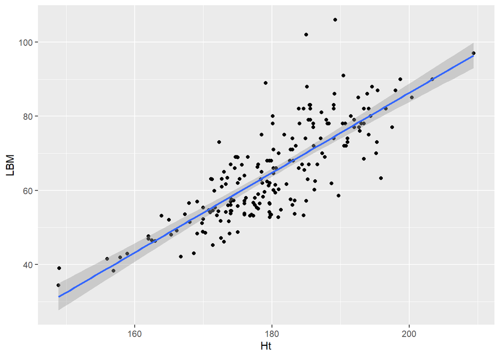

```r
ggplot(athlete, aes(x = Ht, y = LBM)) +
  geom_point() +
  geom_smooth(method = "lm")
```

#### Part b Run Simple Linear Regression with the above variables. Interpret the coefficient estimates in context to the problem.

For every additional centimeter in height we expect lean body mass to increase by 1.077 units. Since the p-value for `Ht` is basically 0, we conclude that it is significantly associated with lean body mass.

```r
lm.fit.simp <- lm(LBM ~ Ht, data = athlete)
summary(lm.fit.simp)
```

```
##
## Call:
## lm(formula = LBM ~ Ht, data = athlete)
##
## Residuals:
##     Min      1Q  Median      3Q     Max
## -18.566  -4.913  -0.556   4.171  31.853
##
## Coefficients:
##              Estimate Std. Error t value Pr(>|t|)
## (Intercept) -129.0947    10.2259  -12.62   <2e-16 ***
## Ht             1.0770     0.0567   19.00   <2e-16 ***
## ---
## Signif. codes:  0 '***' 0.001 '**' 0.01 '*' 0.05 '.' 0.1 ' ' 1
##
## Residual standard error: 7.825 on 200 degrees of freedom
## Multiple R-squared:  0.6434, Adjusted R-squared:  0.6416
## F-statistic: 360.8 on 1 and 200 DF,  p-value: < 2.2e-16
```

#### Part c Add RCC as a predictor (along with Ht). Interpret the coefficients from the multiple linear regression model.

We say that each additional centimeter in height leads to an average increase in lean body mass of 0.931 units, while holding red blood cell count constant. For each additional unit increase in red blood cell count we expect lean body mass to increase by 8.6195 units, while holding heigh constant. They are both significantly associated with `LBM` because both p-values are very small.

```r
lm.fit.mult <- lm(LBM ~ Ht + RCC, data = athlete)
summary(lm.fit.mult)
```

```
##
## Call:
## lm(formula = LBM ~ Ht + RCC, data = athlete)
##
## Residuals:
##      Min       1Q   Median       3Q      Max
## -16.7985  -4.7171  -0.4473   3.8109  26.0909
##
## Coefficients:
##               Estimate Std. Error t value Pr(>|t|)
## (Intercept) -143.55761    9.23789 -15.540  < 2e-16 ***
## Ht             0.93146    0.05368  17.352  < 2e-16 ***
## RCC            8.61950    1.14102   7.554  1.5e-12 ***
## ---
## Signif. codes:  0 '***' 0.001 '**' 0.01 '*' 0.05 '.' 0.1 ' ' 1
##
## Residual standard error: 6.915 on 199 degrees of freedom
## Multiple R-squared:  0.7229, Adjusted R-squared:  0.7201
## F-statistic: 259.5 on 2 and 199 DF,  p-value: < 2.2e-16
```

#### Part d Add Sex as a predictor to the linear model (along with Ht and RCC). Which Sex was given the value 1 by the dummy variable? Interpret the estimated coefficient from the model in context to the problem.

We know that the males got a dummy variable value of 1 because the `m` is pasted to `Sex` in the summary. This means that we expect males to have 10.067 more units of lean body mass than females (i.e. going from 0 to 1), while holding height and red blood cell count constant. Once we added `Sex` as a predictor in the model the p-value for `RCC` got much bigger. This is most likely because `Sex` and `RCC` are highly correlated. So, given `Sex` is already in the model then `RCC` doesn’t explain all that much additional information with `LBM`.

```r
lm.fit.sex <- lm(LBM ~ Ht + RCC + Sex, data = athlete)
summary(lm.fit.sex)
```

```
##
## Call:
## lm(formula = LBM ~ Ht + RCC + Sex, data = athlete)
##
## Residuals:
##      Min       1Q   Median       3Q      Max
## -12.0460  -4.0102  -0.4716   2.9620  27.4395
##
## Coefficients:
##              Estimate Std. Error t value Pr(>|t|)
## (Intercept) -86.02107   11.11413  -7.740 5.00e-13 ***
## Ht            0.74254    0.05345  13.892  < 2e-16 ***
## RCC           2.55956    1.28316   1.995   0.0474 *
## Sexm         10.06727    1.32290   7.610 1.09e-12 ***
## ---
## Signif. codes:  0 '***' 0.001 '**' 0.01 '*' 0.05 '.' 0.1 ' ' 1
##
## Residual standard error: 6.098 on 198 degrees of freedom
## Multiple R-squared:  0.7856, Adjusted R-squared:  0.7823
## F-statistic: 241.8 on 3 and 198 DF,  p-value: < 2.2e-16
```

#### Part e Look at the scatterplot between Ht and LBM with different color points for each Sex. Fit the OLS line for each Sex as well. Do you think there’s a significant interaction effect between Sex and Ht. Explain why or why not from the plot.

The two fitted lines have similar slopes so there’s probably not a significant interaction effect between `Sex` and `Ht`. An interaction effect means that the slope of the line changes for different values of `Sex`.

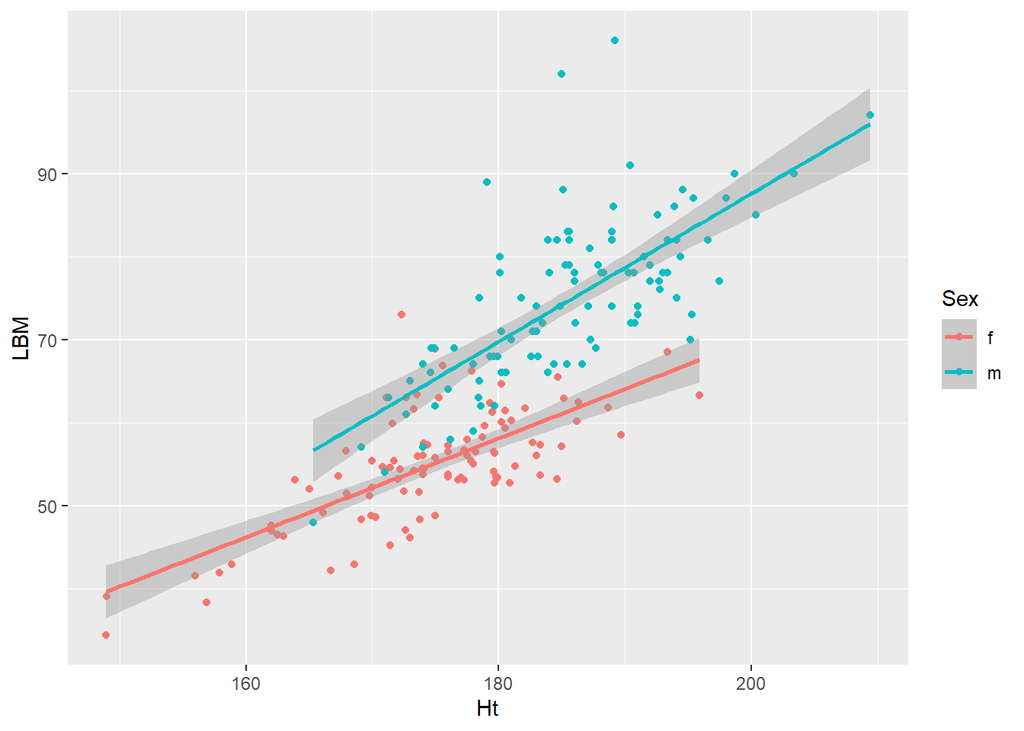

```r
ggplot(athlete, aes(x = Ht, y = LBM, color = Sex)) +
  geom_point() +
  geom_smooth(method = "lm")
```

#### Part f-g Use the predict( ) function to predict the LBM of a female athlete that is 180 cms tall and has a red blood cell count of 4.5.

#### Use the predict( ) function to predict the LBM of a female athlete that is 181 cms tall and has a red blood cell count of 4.5. Compute the difference between this value and the value from the previous part. Compare this to a coefficient estimate from the summary( ) function.

```r
p.1 <- predict(lm.fit.sex, newdata = data.frame(Ht = 180, RCC = 4.5, Sex = "f"))
  p.1
```

```
##        1
## 59.15349
```

```r
p.2 <- predict(lm.fit.sex, newdata = data.frame(Ht = 181, RCC = 4.5, Sex = "f"))
  p.2
```

```
##        1
## 59.89603
```

The difference between the two predicted values is 0.7425363, which is the estimated coefficient for `Ht` from part (d). This is exactly what we mean by the slope and `holding the other variables constant.